# 17_circ_params_from_graph

## 17_circ_params_from_graph

#### Question

1. A circle is the collection of points equally distant from a center. If the circle has a center $(h,k)$ and a radius $r$, then we can represent that circle in the $xy$-plane using the following standard form of a circle:

   $$(x-h)^2+(y-k)^2 = r^2$$

   Notice that this equation looks like the Pythagorean Equation (from the Pythagorean Theorem): $a^2+b^2=c^2$. It also looks like the distance formula, were $r$ is the distance, $x-h$ is the horizontal displacement, and $y-k$ is the vertical displacement.

   Consider the circle graphed below. Some of the points on the circle are $(-10,-4)$, $(-12,-2)$, $(-14,-4)$, and $(-12,-6)$.

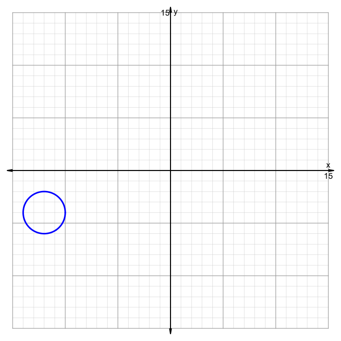

   Find the values of the parameters $h$, $k$, and $r$.
   - $h=$
   - $k=$
   - $r=$

#### Question

2. A circle is the collection of points equally distant from a center. If the circle has a center $(h,k)$ and a radius $r$, then we can represent that circle in the $xy$-plane using the following standard form of a circle:

   $$(x-h)^2+(y-k)^2 = r^2$$

   Notice that this equation looks like the Pythagorean Equation (from the Pythagorean Theorem): $a^2+b^2=c^2$. It also looks like the distance formula, were $r$ is the distance, $x-h$ is the horizontal displacement, and $y-k$ is the vertical displacement.

   Consider the circle graphed below. Some of the points on the circle are $(-3,2)$, $(-7,6)$, $(-11,2)$, and $(-7,-2)$.

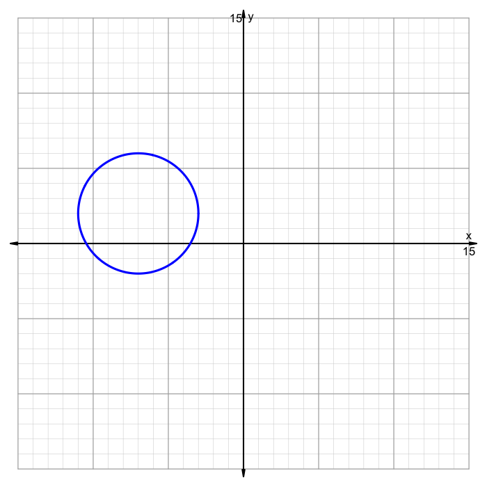

   Find the values of the parameters $h$, $k$, and $r$.
   - $h=$
   - $k=$
   - $r=$

#### Question

3. A circle is the collection of points equally distant from a center. If the circle has a center $(h,k)$ and a radius $r$, then we can represent that circle in the $xy$-plane using the following standard form of a circle:

   $$(x-h)^2+(y-k)^2 = r^2$$

   Notice that this equation looks like the Pythagorean Equation (from the Pythagorean Theorem): $a^2+b^2=c^2$. It also looks like the distance formula, were $r$ is the distance, $x-h$ is the horizontal displacement, and $y-k$ is the vertical displacement.

   Consider the circle graphed below. Some of the points on the circle are $(10,-12)$, $(8,-10)$, $(6,-12)$, and $(8,-14)$.

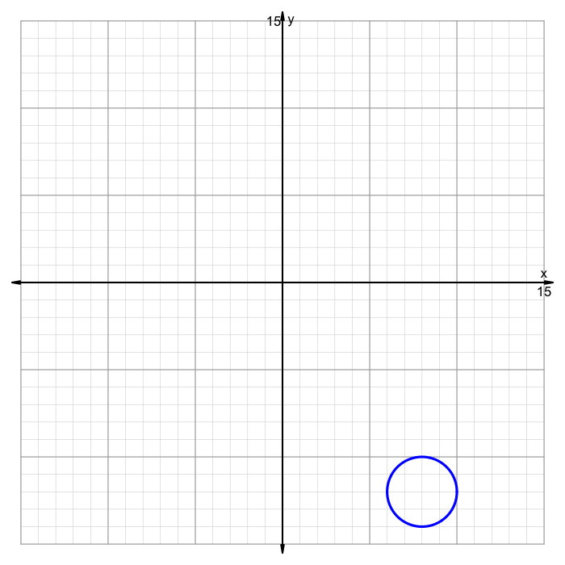

   Find the values of the parameters $h$, $k$, and $r$.
   - $h=$
   - $k=$
   - $r=$

#### Question

4. A circle is the collection of points equally distant from a center. If the circle has a center $(h,k)$ and a radius $r$, then we can represent that circle in the $xy$-plane using the following standard form of a circle:

   $$(x-h)^2+(y-k)^2 = r^2$$

   Notice that this equation looks like the Pythagorean Equation (from the Pythagorean Theorem): $a^2+b^2=c^2$. It also looks like the distance formula, were $r$ is the distance, $x-h$ is the horizontal displacement, and $y-k$ is the vertical displacement.

   Consider the circle graphed below. Some of the points on the circle are $(7,7)$, $(4,10)$, $(1,7)$, and $(4,4)$.

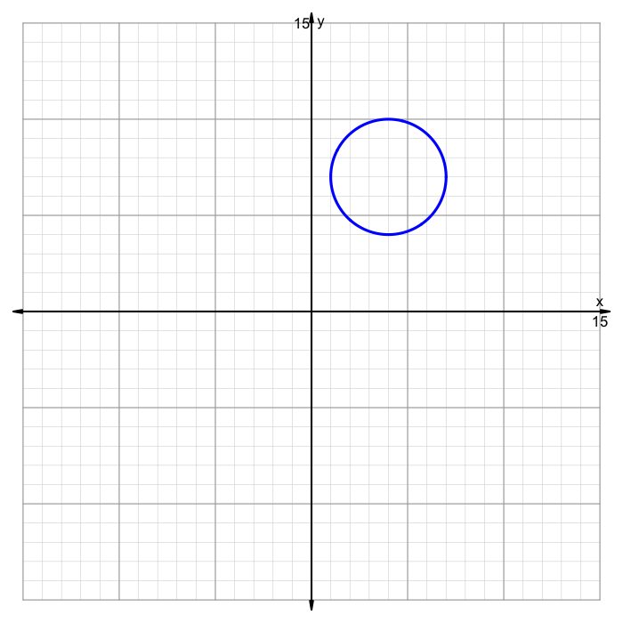

   Find the values of the parameters $h$, $k$, and $r$.
   - $h=$
   - $k=$
   - $r=$

#### Question

5. A circle is the collection of points equally distant from a center. If the circle has a center $(h,k)$ and a radius $r$, then we can represent that circle in the $xy$-plane using the following standard form of a circle:

   $$(x-h)^2+(y-k)^2 = r^2$$

   Notice that this equation looks like the Pythagorean Equation (from the Pythagorean Theorem): $a^2+b^2=c^2$. It also looks like the distance formula, were $r$ is the distance, $x-h$ is the horizontal displacement, and $y-k$ is the vertical displacement.

   Consider the circle graphed below. Some of the points on the circle are $(5,-4)$, $(-2,3)$, $(-9,-4)$, and $(-2,-11)$.

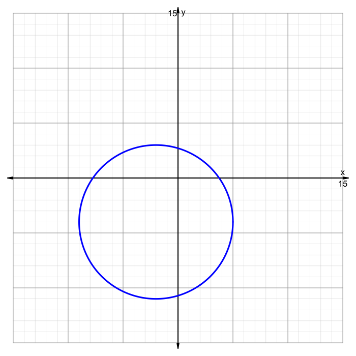

   Find the values of the parameters $h$, $k$, and $r$.
   - $h=$
   - $k=$
   - $r=$

#### Question

6. A circle is the collection of points equally distant from a center. If the circle has a center $(h,k)$ and a radius $r$, then we can represent that circle in the $xy$-plane using the following standard form of a circle:

   $$(x-h)^2+(y-k)^2 = r^2$$

   Notice that this equation looks like the Pythagorean Equation (from the Pythagorean Theorem): $a^2+b^2=c^2$. It also looks like the distance formula, were $r$ is the distance, $x-h$ is the horizontal displacement, and $y-k$ is the vertical displacement.

   Consider the circle graphed below. Some of the points on the circle are $(6,-3)$, $(-2,5)$, $(-10,-3)$, and $(-2,-11)$.

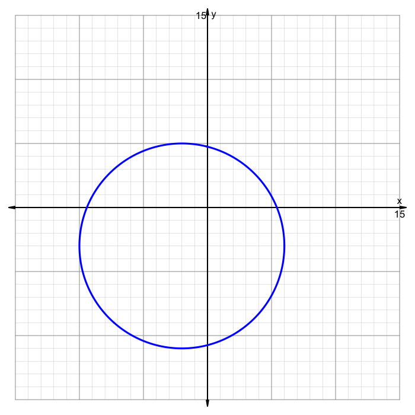

   Find the values of the parameters $h$, $k$, and $r$.
   - $h=$
   - $k=$
   - $r=$

#### Question

7. A circle is the collection of points equally distant from a center. If the circle has a center $(h,k)$ and a radius $r$, then we can represent that circle in the $xy$-plane using the following standard form of a circle:

   $$(x-h)^2+(y-k)^2 = r^2$$

   Notice that this equation looks like the Pythagorean Equation (from the Pythagorean Theorem): $a^2+b^2=c^2$. It also looks like the distance formula, were $r$ is the distance, $x-h$ is the horizontal displacement, and $y-k$ is the vertical displacement.

   Consider the circle graphed below. Some of the points on the circle are $(11,4)$, $(6,9)$, $(1,4)$, and $(6,-1)$.

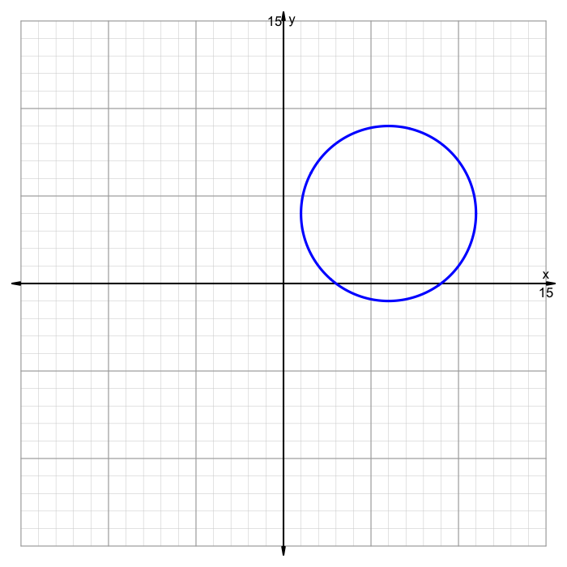

   Find the values of the parameters $h$, $k$, and $r$.
   - $h=$
   - $k=$
   - $r=$

#### Question

8. A circle is the collection of points equally distant from a center. If the circle has a center $(h,k)$ and a radius $r$, then we can represent that circle in the $xy$-plane using the following standard form of a circle:

   $$(x-h)^2+(y-k)^2 = r^2$$

   Notice that this equation looks like the Pythagorean Equation (from the Pythagorean Theorem): $a^2+b^2=c^2$. It also looks like the distance formula, were $r$ is the distance, $x-h$ is the horizontal displacement, and $y-k$ is the vertical displacement.

   Consider the circle graphed below. Some of the points on the circle are $(-1,-2)$, $(-4,1)$, $(-7,-2)$, and $(-4,-5)$.

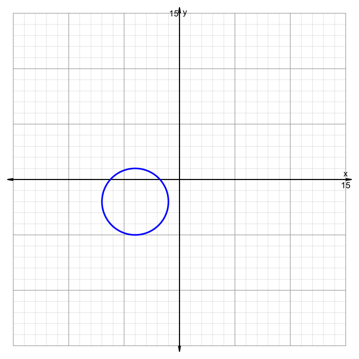

   Find the values of the parameters $h$, $k$, and $r$.
   - $h=$
   - $k=$
   - $r=$